# Machine Learning for Health Care: Homework 2

Xinmi Li

February 27, 2017

## Overview

Homework 2 is about applying what you have learned in class into analysis in R. You will draw from both your learning in lecture and discussion with the skills you are developing in the workshop sessions.

The homework is split into two parts: short questions to illustrate concepts, and a secondary analysis of data from a randomized controlled trial.

**Homework 2 is due March 6th at the beginning of class.**

### Data set

The data set used for this homework comes from the International Stroke Trial. This was a study comparing the effectiveness of medications in a populaton of patients who had suffered strokes. The publication was in the leading British medical journal Lancet: http://www.sciencedirect.com/science/article/pii/S0140673697040117 (you may need to be on campus or use VPN)

The data set is here: http://datashare.is.ed.ac.uk/bitstream/handle/10283/128/IST_corrected.csv (more information here: http://datashare.is.ed.ac.uk/handle/10283/128)

The variable definitions files are also helpful: http://datashare.is.ed.ac.uk/bitstream/handle/10283/128/IST_variables.pdf http://datashare.is.ed.ac.uk/bitstream/handle/10283/128/IST_variables.csv

## Objectives

- git
- debug
- inject belief/knowledge by shifting from ML to MAP estimates
- choosing MCAR, MAR, MNAR; choosing indicator and/or imputation
- run machine learning algorithms: LR, NB, TAN, decision tree
- reporting performance, using ggplot

## Instructions

For this homework, you will use git. **To submit the homework, email me a link to your git repository.** I should be able to type “git clone ” and have it download from a cloud service (github, bitbucket, etc). Note that if it is a private repository, you will need to permit me access to it (please provide access to jeremy.weiss@gmail.com).

Your git repository should contain at least two commits with useful comments on what has changed from the previous version(s). This should be visible when I type in `git log`. The submission I will grade is at the HEAD revision unless specified otherwise in your email. Include your .Rmd file and your .html file solutions in the repository with your name and andrew ID.

## Part 1: Concept questions (6 points)

The code that follows introduces a toy data set, decision tree model, and two prediction functions.

```r
library(plyr)
library(dplyr)

# synthetic depression data
depressionData = data.frame( # do not change "depressionData"
  pregnant = c(1,0,1,1),
  depressed = c("yes","yes","no","no") %>% as.factor(),
  hospitalized = c(1, 0, 0, 0) %>% as.logical()
) %>% tbl_df()

# tree: a model that outputs the odds of hospitalization from inputs of data (datums)
tree = data.frame( # do not change "tree"
  splitVariable = c("depressed", "pregnant", NA, NA, NA),
  split = c("yes", 1, NA, NA, NA),
  trueChild = c(2, 4, NA, NA, NA),
  falseChild = c(3, 5, NA, NA, NA),
  odds = c(NA, NA, 0.1, 2, 3)
)

predictOddsOnDataSet = function(tree, data, active = 1) {
  # get the predicted odds for each row in data
  apply(data, 1, (function(x) {predictedOdds(tree=tree, x, active=1)})  )
}

predictedOdds = function(tree, datum, active = 1) { # active is the node#

  if(is.na(tree[active,"splitVariable"])) { # leaf of tree, so output value

    return(tree$odds[active])

  } else { # internal node of tree, so continue down tree to true/false child

    # Categorize datum by comparing the variable value with the n split variable (n=active) in tree. With the split criterion in tree met, set the active as the true child node#, and try to get the odds OR split the child variable again... until get the odds
    if((datum[[tree[active,"splitVariable"] %>% as.character]] %>% as.character) == tree[active,"split"]) {
      return(predictedOdds(tree, datum, active = tree[active,"trueChild"]))
    } else {
      # with the split criterion in tree not met, set the active as the false child node#, and try to get the odds OR split the child variable again... until get the odds
      return(predictedOdds(tree, datum, active = tree[active,"falseChild"]))
    }

  }

}

# goal: run predictOddsOnDataSet(tree, depressionData)
predicted.odds <- predictOddsOnDataSet(tree, depressionData)
predicted.odds
```

```
## [1] 2.0 3.0 0.1 0.1
```

First, verify to yourself that, for the fourth patient in `depressionData`, the tree should have output an odds of 0.1.

Fix the function `predictedOdds` so that `predictedOddsOnDataSet` outputs the odds for each patient in data. Use the debugger functions like `debugOnce(predictedOdds)` or `browser()` to inspect the code.

What did you change?

Quote marks around trueChild and falseChild added, so the active will be set as the true/false child node of the current internal node.

Add a column of the predicted probabilities of hospitalization to depressionData. Display it.

```r
depressionData$predicted.prob <- predicted.odds/(1+predicted.odds)
depressionData
```

```
## # A tibble: 4 × 4
##   pregnant depressed hospitalized predicted.prob
##      <dbl>    <fctr>        <lgl>          <dbl>
## 1        1       yes         TRUE     0.66666667
## 2        0       yes        FALSE     0.75000000
## 3        1        no        FALSE     0.09090909
## 4        1        no        FALSE     0.09090909
```

Using a threshold probability of 0.5, what is:

- the accuracy of the model?
- the sensitivity of the model?
- the specificity of the model?
- the precision of the model?
- the recall of the model?

```r
prediction <- depressionData$predicted.prob >= 0.5
TP <- sum(as.numeric(depressionData$hospitalized == 1 & prediction == 1))
FP <- sum(as.numeric(depressionData$hospitalized == 0 & prediction == 1))
TN <- sum(as.numeric(depressionData$hospitalized == 0 & prediction == 0))
FN <- sum(as.numeric(depressionData$hospitalized == 1 & prediction == 0))
```

The accuracy is 0.75. The sensitivity is 1. The specificity is 0.6666667. The precision is 0.5. The recall is 1.

Suppose you want to know the prevalence of diabetes in Pittsburgh. If you randomly survey 10 Pittsburghers and 5 of them state they have diabetes:

- what is the maximum likelihood estimate for the prevalence of diabetes?

```r
p <- seq(0,1,0.001)
MLE <- p[which.max(dbeta(p, shape1 = 5, shape2 = 5))]
MLE
```

```
## [1] 0.5
```

The maximum likelihood estimate is 0.5.

- given your strong belief specified by a beta prior of $\alpha = 11, \beta = 21$, what is the maximum a posteriori estimate for the prevalence of diabetes?

```r
MLE.new <- p[which.max(dbeta(p, shape1 = 5+11, shape2 = 5+21))]
MLE.new
```

```
## [1] 0.375
```

With prior belief, the maximum posteriori estimate is 0.375.

## Part 2: Analysis (9 points)

#### Preliminaries

- **Y:** What was the definition of the primary outcome in this study?
- What is (are) the variable name(s) for the outcome?
- **U:** what is (are) the variable name(s) for the intervention, and what is (are) their possible values?
- **V, W:** describe the covariates included and the population being studied.

**Y:**

The primary outcomes are: (a) the incidence of death from any cause within 14 days, with the variable name “ID14”, and (b) the incidence of death or dependency at 6 months, with the variable name “FDEAD” and “FDENNIS”.

**U:**

The variable names for intervention are: “RXASP” with possible values {Y, N} and “RXHEP” with possible values {M, L, N}.

**V, W:**

The covariates are delay in hours from symptoms, age, sex, onset conditions, conscious level, cardiac rhythm, systolic BP, stroke syndrom, leg weakness, CT scan, appearance of pre-randomisation CT, and pre-randomisation antithrombotic therapy.

The studied population are 19435 patients who are eligible if: (a) with evidence of an acute stroke with onset less than 48 hours previously, (b) with no evidence of intracranial haemorrhage, and (c) with no clear indications for orcontradications to heparin or aspirin. The fundamental criterion is physician’s uncertaining whether or not to assign either or both of the trial treatments to the particular patient. The exclusions are: only a small likelihood of worthwhile benefit or a high risk of adverse effects on the patiens.

- Construct a so-called Table 1 for groups of {aspirin, no aspirin} use, including information on age, gender, systolic blood pressure, and conscious state.

```r
library(knitr)
IST <- data.frame(read.csv(file = "/Users/Xinmi/git/ML_for_HC_hw2/IST.csv", header = TRUE))
Table1data <- IST %>%
  subset(select = c("RXASP", "AGE", "SEX", "RSBP","RCONSC")) %>%
  transform(AGE = as.factor(cut(IST$AGE, breaks = c(0,50,60,70,80,Inf))),
            RSBP = as.factor(cut(IST$RSBP, breaks = c(0,140,160,170,180,Inf))),
            RCONSC = mapvalues(RCONSC, c("F", "D", "U"), c("Fully alert", "Drowsy", "Unconscious")),
            Number = 1:nrow(IST))

Asp.Age <- aggregate(Number ~ AGE + RXASP, data = Table1data, length)
Asp.Sex <- aggregate(Number ~ SEX + RXASP, data = Table1data, length)
Asp.RSBP <- aggregate(Number ~ RSBP + RXASP, data = Table1data, length)
Asp.RCONSC <- aggregate(Number ~ RCONSC + RXASP, data = Table1data, length)

Table1 <- list(Asp.Age, Asp.Sex, Asp.RSBP, Asp.RCONSC) %>%
  kable

Table1
```

| AGE | RXASP | Number |
| --- | --- | --- |
| (0,50] | N | 526 |
| (50,60] | N | 1076 |
| (60,70] | N | 2302 |
| (70,80] | N | 3418 |
| (80,Inf] | N | 2393 |
| (0,50] | Y | 535 |
| (50,60] | Y | 1017 |
| (60,70] | Y | 2346 |
| (70,80] | Y | 3430 |
| (80,Inf] | Y | 2392 |

| SEX | RXASP | Number |
| --- | --- | --- |
| F | N | 4461 |
| M | N | 5254 |
| F | Y | 4567 |
| M | Y | 5153 |

| RSBP | RXASP | Number |
| --- | --- | --- |
| (0,140] | N | 2873 |
| (140,160] | N | 2833 |
| (160,170] | N | 1127 |
| (170,180] | N | 1121 |
| (180,Inf] | N | 1761 |
| (0,140] | Y | 2970 |
| (140,160] | Y | 2798 |
| (160,170] | Y | 1126 |
| (170,180] | Y | 1066 |
| (180,Inf] | Y | 1760 |

| RCONSC | RXASP | Number |
| --- | --- | --- |
| Drowsy | N | 2127 |
| Fully alert | N | 7458 |
| Unconscious | N | 130 |
| Drowsy | Y | 2127 |
| Fully alert | Y | 7463 |
| Unconscious | Y | 130 |

#### Machine learning analysis

Note: for this analysis, use a simple 50-50 train-test split.

Let our outcome of interest be “dead or dependent at 6 months”, i.e. so that we have a binary classification problem. What percent of patients are dead or dependent at 6 months in your train set and test set?

```r
ordering <- sample(1:nrow(IST))
train <- IST[ordering[1:round(0.5*nrow(IST))],]
test <- IST[-ordering[1:round(0.5*nrow(IST))], ]
```

The percent of patients dead or dependent at 6 months is 61.82% in the train set and 62.65% in the test set.

Choose which variables to include in your model. For example, remove variables for outcomes at 14 days (because if you are dead at 14 days you are certainly dead at 6 months). Moreover, you should remove all features measured after baseline if you want to make a prediction based on baseline data. Similarly, specific indicators of the outcome should also be removed, since those are measurements past the baseline that are not our outcome of interest. For these reasons, you will need to remove clusters of variables. Justify your approach.

```r
y <- c("FDEAD", "FDENNIS")
v <- c("RDELAY", "RCONSC", "SEX", "AGE", "RSLEEP", "RATRIAL", "RCT", "RVISINF", "RHEP24", "RASP3", "RSBP", "STYPE")
u <- c("RXASP", "RXHEP")

train2 <- train %>%
  subset(select = c(y, v, u)) %>%
  transform(Outcome = as.numeric(FDEAD == "Y" | FDENNIS == "Y")) %>%
  subset(select = -c(FDEAD, FDENNIS))

test2 <- test %>%
  subset(select = c(y, v, u)) %>%
  transform(Outcome = as.numeric(FDEAD == "Y" | FDENNIS == "Y")) %>%
  subset(select = -c(FDEAD, FDENNIS))
```

Only outcomes, covariates, and intervention variables are kept in the train and test sets. The outcome is transformed into a binary value that uses 1 for “death or dependency at 6 months”.

Of the remaining variables, decide whether to exclude variables with missing data, impute them, and/or use indicator variables. (Note that if you choose multiple imputation for some variables, you would need to pool the results when evaluating performance, however for homework you may just use the first imputed data set). Justify your approach.

```r
library(mice)
library(lattice)

train3 <- train2 %>%
  apply(2, function(x) {mapvalues(x, "", NA)}) %>%
  as.data.frame()
test3 <- test2 %>%
  apply(2, function(x) {mapvalues(x, "", NA)}) %>%
  as.data.frame()
md.pattern(train3)
```

```
##      RDELAY RCONSC SEX AGE RSLEEP RCT RVISINF RSBP STYPE RXASP RXHEP
## 9262      1      1   1   1      1   1       1    1     1     1     1
##  289      1      1   1   1      1   1       1    1     1     1     1
##  167      1      1   1   1      1   1       1    1     1     1     1
##           0      0   0   0      0   0       0    0     0     0     0
##      Outcome RHEP24 RATRIAL RASP3
## 9262       1      1       1     1    0
##  289       1      1       0     0    2
##  167       1      0       0     0    3
##            0    167     456   456 1079
```

```r
md.pattern(test3)
```

```
##      RDELAY RCONSC SEX AGE RSLEEP RCT RVISINF RSBP STYPE RXASP RXHEP
## 9189      1      1   1   1      1   1       1    1     1     1     1
##  351      1      1   1   1      1   1       1    1     1     1     1
##  177      1      1   1   1      1   1       1    1     1     1     1
##           0      0   0   0      0   0       0    0     0     0     0
##      Outcome RHEP24 RATRIAL RASP3
## 9189       1      1       1     1    0
##  351       1      1       0     0    2
##  177       1      0       0     0    3
##            0    177     528   528 1233
```

```r
train3new <- train3[-which(is.na(train3$RATRIAL)),]
test3new <- test3[-which(is.na(test3$RATRIAL)),]

md.pattern(train3new)
```

```
##      RDELAY RCONSC SEX AGE RSLEEP RATRIAL RCT RVISINF RHEP24 RASP3 RSBP
## [1,]      1      1   1   1      1       1   1       1      1     1    1
## [2,]      0      0   0   0      0       0   0       0      0     0    0
##      STYPE RXASP RXHEP Outcome
## [1,]     1     1     1       1 0
## [2,]     0     0     0       0 0
```

```r
md.pattern(test3new)
```

```
##      RDELAY RCONSC SEX AGE RSLEEP RATRIAL RCT RVISINF RHEP24 RASP3 RSBP
## [1,]      1      1   1   1      1       1   1       1      1     1    1
## [2,]      0      0   0   0      0       0   0       0      0     0    0
##      STYPE RXASP RXHEP Outcome
## [1,]     1     1     1       1 0
## [2,]     0     0     0       0 0
```

From the missing pattern we can find that the missing values are all related to variables RHEP24, RATRIAL, and RSAP3 in both train set and test set. For RATRIAL we know that there are 984 patients not coded this in pilot phase, the missing values are definitely missed not at random, so I just remove these instances. For RHEP24 and RSAP3, the missing values are only a small part of the dataset, so they might be missing at random and will be imputed. However, after removing the instances with missing RATRIAL value, there is no missing value for other variables, which means that the missing values are related to the instances in pilot phase which should be removed. Therefore, no imputation for missing values needed.

Use the following machine learning algorithms: logistic regression, naive Bayes, Tree Augmented Naive Bayes, and decision tree (specify any parameters you set that are not the default). The packages that you may find useful here are: “glm”, “bnlearn”, and “rpart”, but you may use others if desired. In a table, report the accuracy with 95% confidence intervals for each algorithm.

Logistic Regression

```r
train.lr <- train3new %>%
  transform(RDELAY = as.numeric(RDELAY), AGE = as.numeric(AGE), RSBP = as.numeric(RSBP))

test.lr <- test3new  %>%
  transform(RDELAY = as.numeric(RDELAY), AGE = as.numeric(AGE), RSBP = as.numeric(RSBP))

# Remove the factors with less than 2 levels.
col.level <- function(x, col) {
  if (is.factor(x[,col])) {
    length(levels(x[,col]))
  } else {999}
}

train.lr.remove <- 0
for (i in 1:ncol(train.lr)) {
  if (col.level(train.lr, i) < 2) {
    train.lr.remove <- c(train.lr.remove, i)
  }
}

test.lr.remove <- 0
for (i in 1:ncol(test.lr)) {
  if (col.level(test.lr, i) < 2) {
    test.lr.remove <- c(test.lr.remove, i)
  }
}


if (length(train.lr.remove)>1 | length(test.lr.remove)>1) {
  train.lr2 <- train.lr[,-c(train.lr.remove[-1], test.lr.remove[-1])]
  test.lr2 <- test.lr[,-c(train.lr.remove[-1], test.lr.remove[-1])]
} else {
  train.lr2 <- train.lr
  test.lr2 <- test.lr
}



# Remove the row in test set with level of factors not seen in train set (unable to predict) and drop the unused levels.
test.lr.rowdis <- 0
for (i in 1:ncol(test.lr2)) {
  for (j in 1:nrow(test.lr2)) {
    if (is.factor(test.lr2[,i]) & !(test.lr2[j,i] %in% train.lr2[,i])) {
      test.lr.rowdis <- c(test.lr.rowdis, j)
    }
  }
}

train.lr3 <- droplevels.data.frame(train.lr2)

if (length(test.lr.rowdis)>1) {
  test.lr3 <- test.lr2[-test.lr.rowdis[-1],] %>%
    droplevels.data.frame
} else {
  test.lr3 <- test.lr2 %>%
    droplevels.data.frame
}


# Build the model, fit and test it.
lr <- glm(Outcome == 1 ~ ., family=binomial(link="logit"), data = train.lr3)
summary(lr)
```

```
##
## Call:
## glm(formula = Outcome == 1 ~ ., family = binomial(link = "logit"),
##     data = train.lr3)
##
## Deviance Residuals:
##     Min       1Q   Median       3Q      Max
## -3.0845  -1.0082   0.4485   0.9081   2.2093
##
## Coefficients:
##               Estimate Std. Error z value Pr(>|z|)
## (Intercept) -0.5443428  0.1784296  -3.051 0.002283 **
## RDELAY       0.0001751  0.0020182   0.087 0.930876
## RCONSCF     -1.3215426  0.0798422 -16.552  < 2e-16 ***
## RCONSCU      1.9255216  0.5203381   3.701 0.000215 ***
## SEXM        -0.3285383  0.0492741  -6.668 2.60e-11 ***
## AGE          0.0459807  0.0022876  20.100  < 2e-16 ***
## RSLEEPY      0.0267407  0.0528707   0.506 0.613015
## RATRIALY     0.3497521  0.0727933   4.805 1.55e-06 ***
## RCTY        -0.5456384  0.0586270  -9.307  < 2e-16 ***
## RVISINFY     0.3654869  0.0599477   6.097 1.08e-09 ***
## RHEP24Y      0.1241778  0.1642103   0.756 0.449522
## RASP3Y       0.1812559  0.0592555   3.059 0.002222 **
## RSBP        -0.0018026  0.0009035  -1.995 0.046015 *
## STYPEOTH    -0.5622236  0.4925516  -1.141 0.253682
## STYPEPACS    0.1270606  0.0585875   2.169 0.030103 *
## STYPEPOCS   -0.3181684  0.0822829  -3.867 0.000110 ***
## STYPETACS    1.0813111  0.0815758  13.255  < 2e-16 ***
## RXASPY      -0.0806527  0.0481619  -1.675 0.094010 .
## RXHEPM      -0.0803849  0.0677195  -1.187 0.235217
## RXHEPN      -0.0506548  0.0590987  -0.857 0.391378
## ---
## Signif. codes:  0 '***' 0.001 '**' 0.01 '*' 0.05 '.' 0.1 ' ' 1
##
## (Dispersion parameter for binomial family taken to be 1)
##
##     Null deviance: 12300  on 9261  degrees of freedom
## Residual deviance: 10166  on 9242  degrees of freedom
## AIC: 10206
##
## Number of Fisher Scoring iterations: 6
```

```r
predict.lr <- predict(lr, test.lr3)

summary.lr <- as.vector(predict.lr>=0.5) %>%
  table(test.lr3$Outcome)
summary.lr
```

```
##
## .          0    1
##   FALSE 2682 2152
##   TRUE   741 3614
```

```r
accuracy.lr <- (summary.lr[1,1]+summary.lr[2,2])/sum(colSums(summary.lr))
error.lr <- 1 - accuracy.lr
CI.lr.lower <- accuracy.lr - 1.96 * sqrt(error.lr*accuracy.lr/sum(colSums(summary.lr)))
CI.lr.upper <- accuracy.lr + 1.96 * sqrt(error.lr*accuracy.lr/sum(colSums(summary.lr)))

lr.report <- data.frame(accuracy.lr, CI.lr.lower, CI.lr.upper)
lr.report
```

```
##   accuracy.lr CI.lr.lower CI.lr.upper
## 1    0.685167   0.6756706   0.6946635
```

Naive Bayes

```r
library(bnlearn)
train.nb <- train3new %>%
  transform(RDELAY = as.numeric(RDELAY), AGE = as.numeric(AGE), RSBP = as.numeric(RSBP))

test.nb <- test3new%>%
  transform(RDELAY = as.numeric(RDELAY), AGE = as.numeric(AGE), RSBP = as.numeric(RSBP))


# Remove the factors with less than 2 levels.
train.nb.remove <- 0
for (i in 1:ncol(train.nb)) {
  if (col.level(train.nb, i) < 2) {
    train.nb.remove <- c(train.nb.remove, i)
  }
}

test.nb.remove <- 0
for (i in 1:ncol(test.nb)) {
  if (col.level(test.nb, i) < 2) {
    test.nb.remove <- c(test.nb.remove, i)
  }
}

if (length(train.nb.remove)>1 | length(test.nb.remove)>1) {
  train.nb2 <- train.nb[,-c(train.nb.remove[-1], test.nb.remove[-1])]
  test.nb2 <- test.nb[,-c(train.nb.remove[-1], test.nb.remove[-1])]
} else {
  train.nb2 <- train.nb
  test.nb2 <- test.nb
}

# Discretize doesn't work here. Factors transformed from numeric values are still multiple levels after discretization and can't be used to predict outcomes if new factor level appears in test set. Ang since the train and test set are discretize respectively, here I set the same cutoff by using the quantile of train set.

nb.rdelay.break <- quantile(train.nb2$RDELAY, seq(0, 1, 0.25))
nb.age.break <- quantile(train.nb2$AGE, seq(0, 1, 0.25))
nb.rsbp.break <- quantile(train.nb2$RSBP, seq(0, 1, 0.25))

train.nb3 <- train.nb2 %>%
  transform(RDELAY = cut(train.nb2$RDELAY, breaks = nb.rdelay.break, include.lowest=TRUE),
            AGE = cut(train.nb2$AGE, breaks = nb.age.break, include.lowest=TRUE),
            RSBP = cut(train.nb2$RSBP, breaks = nb.rsbp.break, include.lowest=TRUE))

test.nb3 <- test.nb2 %>%
  transform(RDELAY = cut(test.nb2$RDELAY, breaks = nb.rdelay.break, include.lowest=TRUE),
            AGE = cut(test.nb2$AGE, breaks = nb.age.break, include.lowest=TRUE),
            RSBP = cut(test.nb2$RSBP, breaks = nb.rsbp.break, include.lowest=TRUE))

# Remove the row in test set with level of factors not seen in train set (unable to predict) and drop the unused levels.
test.nb.rowdis <- 0
for (i in 1:ncol(test.nb3)) {
  for (j in 1:nrow(test.nb3)) {
    if (!(test.nb3[j,i] %in% train.nb3[,i])) {
      test.nb.rowdis <- c(test.nb.rowdis, j)
    }
  }
}

train.nb4 <- droplevels.data.frame(train.nb3)

if (length(test.lr.rowdis)>1) {
  test.nb4 <- test.nb3[-test.nb.rowdis[-1],] %>%
    droplevels.data.frame
} else{
  test.nb4 <- test.nb3 %>%
  droplevels.data.frame
}


# Build the model, fit and test it.
nb <- naive.bayes(train.nb4, "Outcome")
fitted.nb <- bn.fit(nb, train.nb4)
summary(nb)
```

```
##          Length Class  Mode
## learning  6     -none- list
## nodes    15     -none- list
## arcs     28     -none- character
```

```r
predict.nb <- predict(fitted.nb, test.nb4, prob = TRUE)

summary.nb <- predict(fitted.nb, test.nb4) %>%
  table(test.nb4$Outcome)
summary.nb
```

```
##
## .      0    1
##   0 2289 1566
##   1 1134 4200
```

```r
accuracy.nb <- (summary.nb[1,1]+summary.nb[2,2])/sum(colSums(summary.nb))
error.nb <- 1 - accuracy.nb
CI.nb.lower <- accuracy.nb - 1.96 * sqrt(error.nb*accuracy.nb/sum(colSums(summary.nb)))
CI.nb.upper <- accuracy.nb + 1.96 * sqrt(error.nb*accuracy.nb/sum(colSums(summary.nb)))

nb.report <- data.frame(accuracy.nb, CI.nb.lower, CI.nb.upper)
nb.report
```

```
##   accuracy.nb CI.nb.lower CI.nb.upper
## 1   0.7061704   0.6968567   0.7154842
```

Tree Augmented Naive Bayes

```r
train.tan <- train.nb4
test.tan <- test.nb4

tan <- tree.bayes(train.tan, "Outcome")
fitted.tan <- bn.fit(tan, train.tan)
summary(tan)
```

```
##          Length Class  Mode
## learning  6     -none- list
## nodes    15     -none- list
## arcs     54     -none- character
```

```r
predict.tan <- predict(fitted.tan, test.tan, prob = TRUE)

summary.tan <- predict(fitted.tan, test.tan) %>%
  table(test.tan$Outcome)
summary.tan
```

```
##
## .      0    1
##   0 2127 1350
##   1 1296 4416
```

```r
accuracy.tan <- (summary.tan[1,1]+summary.tan[2,2])/sum(colSums(summary.tan))
error.tan <- 1 - accuracy.tan
CI.tan.lower <- accuracy.tan - 1.96 * sqrt(error.tan*accuracy.tan/sum(colSums(summary.tan)))
CI.tan.upper <- accuracy.tan + 1.96 * sqrt(error.tan*accuracy.tan/sum(colSums(summary.tan)))

tan.report <- data.frame(accuracy.tan, CI.tan.lower, CI.tan.upper)
tan.report
```

```
##   accuracy.tan CI.tan.lower CI.tan.upper
## 1     0.712047    0.7027886    0.7213054
```

Decision Tree

```r
library(rpart)
train.dt <- train.nb4
test.dt <- test.nb4

# Build the model with the loosest constraints.
dt <- rpart(Outcome ~ ., data = train.dt, control=rpart.control(minsplit=2, minbucket=1, cp=0.001))
printcp(dt)
```

```
##
## Classification tree:
## rpart(formula = Outcome ~ ., data = train.dt, control = rpart.control(minsplit = 2,
##     minbucket = 1, cp = 0.001))
##
## Variables actually used in tree construction:
##  [1] AGE     RASP3   RATRIAL RCONSC  RCT     RDELAY  RHEP24  RSBP
##  [9] RSLEEP  RVISINF RXASP   RXHEP   SEX     STYPE
##
## Root node error: 3518/9262 = 0.37983
##
## n= 9262
##
##           CP nsplit rel error  xerror     xstd
## 1  0.0784537      0   1.00000 1.00000 0.013277
## 2  0.0599773      2   0.84309 0.84309 0.012763
## 3  0.0088118      3   0.78312 0.78312 0.012506
## 4  0.0059693      5   0.76549 0.77430 0.012465
## 5  0.0044059      6   0.75952 0.76947 0.012442
## 6  0.0030131      8   0.75071 0.76265 0.012409
## 7  0.0018476     13   0.73565 0.75526 0.012373
## 8  0.0015634     15   0.73195 0.75242 0.012359
## 9  0.0015160     17   0.72882 0.75469 0.012370
## 10 0.0014213     20   0.72428 0.75441 0.012369
## 11 0.0012791     22   0.72143 0.75554 0.012375
## 12 0.0011370     24   0.71887 0.75810 0.012387
## 13 0.0010423     29   0.71319 0.76180 0.012405
## 14 0.0010000     32   0.71006 0.76521 0.012421
```

```r
print(dt)
```

```
## n= 9262
##
## node), split, n, loss, yval, (yprob)
##       * denotes terminal node
##
##    1) root 9262 3518 1 (0.3798316 0.6201684)
##      2) RCONSC=F 7154 3262 1 (0.4559687 0.5440313)
##        4) AGE=[1,47],(47,55] 3892 1670 0 (0.5709147 0.4290853)
##          8) STYPE=LACS,OTH,PACS,POCS 3421 1329 0 (0.6115171 0.3884829)
##           16) AGE=[1,47] 1806  577 0 (0.6805094 0.3194906)
##             32) RCT=Y 1343  384 0 (0.7140730 0.2859270) *
##             33) RCT=N 463  193 0 (0.5831533 0.4168467)
##               66) RSBP=(48,68],(68,88] 223   80 0 (0.6412556 0.3587444) *
##               67) RSBP=[1,48],(88,149] 240  113 0 (0.5291667 0.4708333)
##                134) STYPE=POCS 33    9 0 (0.7272727 0.2727273) *
##                135) STYPE=LACS,OTH,PACS 207  103 1 (0.4975845 0.5024155)
##                  270) RXASP=Y 105   45 0 (0.5714286 0.4285714) *
##                  271) RXASP=N 102   43 1 (0.4215686 0.5784314) *
##           17) AGE=(47,55] 1615  752 0 (0.5343653 0.4656347)
##             34) RCT=Y 1067  447 0 (0.5810684 0.4189316)
##               68) STYPE=LACS,OTH,POCS 573  207 0 (0.6387435 0.3612565)
##                136) RXASP=Y 290   90 0 (0.6896552 0.3103448) *
##                137) RXASP=N 283  117 0 (0.5865724 0.4134276)
##                  274) RSLEEP=N 187   67 0 (0.6417112 0.3582888) *
##                  275) RSLEEP=Y 96   46 1 (0.4791667 0.5208333)
##                    550) RDELAY=[1,9],(9,19] 46   17 0 (0.6304348 0.3695652) *
##                    551) RDELAY=(19,29],(29,48] 50   17 1 (0.3400000 0.6600000) *
##               69) STYPE=PACS 494  240 0 (0.5141700 0.4858300)
##                138) RVISINF=N 255  105 0 (0.5882353 0.4117647) *
##                139) RVISINF=Y 239  104 1 (0.4351464 0.5648536)
##                  278) SEX=M 151   73 1 (0.4834437 0.5165563)
##                    556) RXASP=Y 85   38 0 (0.5529412 0.4470588) *
##                    557) RXASP=N 66   26 1 (0.3939394 0.6060606) *
##                  279) SEX=F 88   31 1 (0.3522727 0.6477273) *
##             35) RCT=N 548  243 1 (0.4434307 0.5565693)
##               70) STYPE=POCS 53   16 0 (0.6981132 0.3018868) *
##               71) STYPE=LACS,PACS 495  206 1 (0.4161616 0.5838384)
##                142) RDELAY=(19,29],(29,48] 233  115 1 (0.4935622 0.5064378)
##                  284) RASP3=N 181   84 0 (0.5359116 0.4640884) *
##                  285) RASP3=Y 52   18 1 (0.3461538 0.6538462) *
```

[output cut: 15 more lines]

```
##                    643) RXHEP=M 43   16 1 (0.3720930 0.6279070) *
##                161) STYPE=LACS,OTH 288  120 1 (0.4166667 0.5833333)
##                  322) RSBP=(68,88],(88,149] 142   68 1 (0.4788732 0.5211268)
##                    644) RASP3=N 114   55 0 (0.5175439 0.4824561)
##                     1288) RDELAY=(9,19],(19,29],(29,48] 85   37 0 (0.5647059 0.4352941) *
##                     1289) RDELAY=[1,9] 29   11 1 (0.3793103 0.6206897) *
##                    645) RASP3=Y 28    9 1 (0.3214286 0.6785714) *
##                  323) RSBP=[1,48],(48,68] 146   52 1 (0.3561644 0.6438356) *
##               81) RATRIAL=Y 112   38 1 (0.3392857 0.6607143) *
##             41) RCT=N 540  196 1 (0.3629630 0.6370370)
##               82) RHEP24=Y 4    0 0 (1.0000000 0.0000000) *
##               83) RHEP24=N 536  192 1 (0.3582090 0.6417910) *
##           21) AGE=(62,80] 1257  342 1 (0.2720764 0.7279236) *
##         11) STYPE=TACS 610   90 1 (0.1475410 0.8524590) *
##      3) RCONSC=D,U 2108  256 1 (0.1214421 0.8785579) *
```

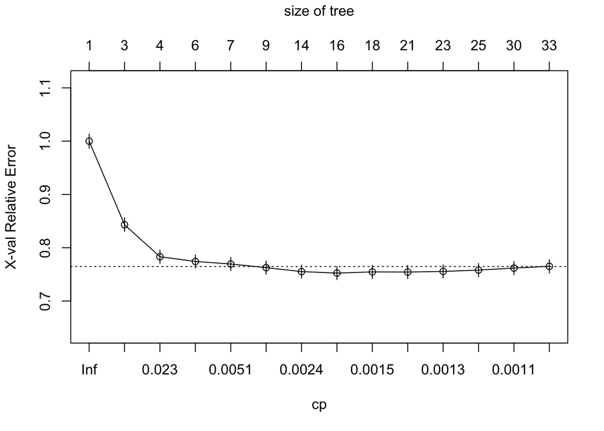

```r
plotcp(dt)
```

```r
# Prune the tree to minimize the cross-validation error.
dt2 <- prune(dt, cp = dt$cptable[which.min(dt$cptable[,"xerror"]),"CP"])
printcp(dt2)
```

```
##
## Classification tree:
## rpart(formula = Outcome ~ ., data = train.dt, control = rpart.control(minsplit = 2,
##     minbucket = 1, cp = 0.001))
##
## Variables actually used in tree construction:
## [1] AGE     RASP3   RATRIAL RCONSC  RCT     RDELAY  RVISINF STYPE
##
## Root node error: 3518/9262 = 0.37983
##
## n= 9262
##
##          CP nsplit rel error  xerror     xstd
## 1 0.0784537      0   1.00000 1.00000 0.013277
## 2 0.0599773      2   0.84309 0.84309 0.012763
## 3 0.0088118      3   0.78312 0.78312 0.012506
## 4 0.0059693      5   0.76549 0.77430 0.012465
## 5 0.0044059      6   0.75952 0.76947 0.012442
## 6 0.0030131      8   0.75071 0.76265 0.012409
## 7 0.0018476     13   0.73565 0.75526 0.012373
## 8 0.0015634     15   0.73195 0.75242 0.012359
```

```r
print(dt2)
```

```
## n= 9262
##
## node), split, n, loss, yval, (yprob)
##       * denotes terminal node
##
##   1) root 9262 3518 1 (0.3798316 0.6201684)
##     2) RCONSC=F 7154 3262 1 (0.4559687 0.5440313)
##       4) AGE=[1,47],(47,55] 3892 1670 0 (0.5709147 0.4290853)
##         8) STYPE=LACS,OTH,PACS,POCS 3421 1329 0 (0.6115171 0.3884829)
##          16) AGE=[1,47] 1806  577 0 (0.6805094 0.3194906) *
##          17) AGE=(47,55] 1615  752 0 (0.5343653 0.4656347)
##            34) RCT=Y 1067  447 0 (0.5810684 0.4189316)
##              68) STYPE=LACS,OTH,POCS 573  207 0 (0.6387435 0.3612565) *
##              69) STYPE=PACS 494  240 0 (0.5141700 0.4858300)
##               138) RVISINF=N 255  105 0 (0.5882353 0.4117647) *
##               139) RVISINF=Y 239  104 1 (0.4351464 0.5648536) *
##            35) RCT=N 548  243 1 (0.4434307 0.5565693)
##              70) STYPE=POCS 53   16 0 (0.6981132 0.3018868) *
##              71) STYPE=LACS,PACS 495  206 1 (0.4161616 0.5838384)
##               142) RDELAY=(19,29],(29,48] 233  115 1 (0.4935622 0.5064378)
##                 284) RASP3=N 181   84 0 (0.5359116 0.4640884) *
##                 285) RASP3=Y 52   18 1 (0.3461538 0.6538462) *
##               143) RDELAY=[1,9],(9,19] 262   91 1 (0.3473282 0.6526718) *
##         9) STYPE=TACS 471  130 1 (0.2760085 0.7239915) *
##       5) AGE=(55,62],(62,80] 3262 1040 1 (0.3188228 0.6811772)
##        10) STYPE=LACS,OTH,PACS,POCS 2652  950 1 (0.3582202 0.6417798)
##          20) AGE=(55,62] 1395  608 1 (0.4358423 0.5641577)
##            40) RCT=Y 855  412 1 (0.4818713 0.5181287)
##              80) RATRIAL=N 743  369 0 (0.5033647 0.4966353)
##               160) STYPE=PACS,POCS 455  201 0 (0.5582418 0.4417582) *
##               161) STYPE=LACS,OTH 288  120 1 (0.4166667 0.5833333) *
##              81) RATRIAL=Y 112   38 1 (0.3392857 0.6607143) *
##            41) RCT=N 540  196 1 (0.3629630 0.6370370) *
##          21) AGE=(62,80] 1257  342 1 (0.2720764 0.7279236) *
##        11) STYPE=TACS 610   90 1 (0.1475410 0.8524590) *
##     3) RCONSC=D,U 2108  256 1 (0.1214421 0.8785579) *
```

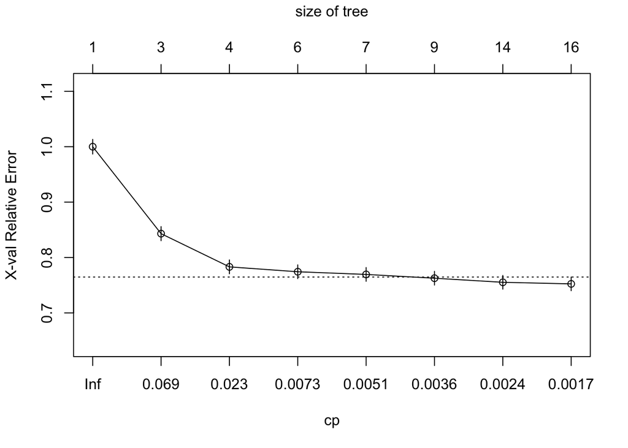

```r
plotcp(dt2)
```

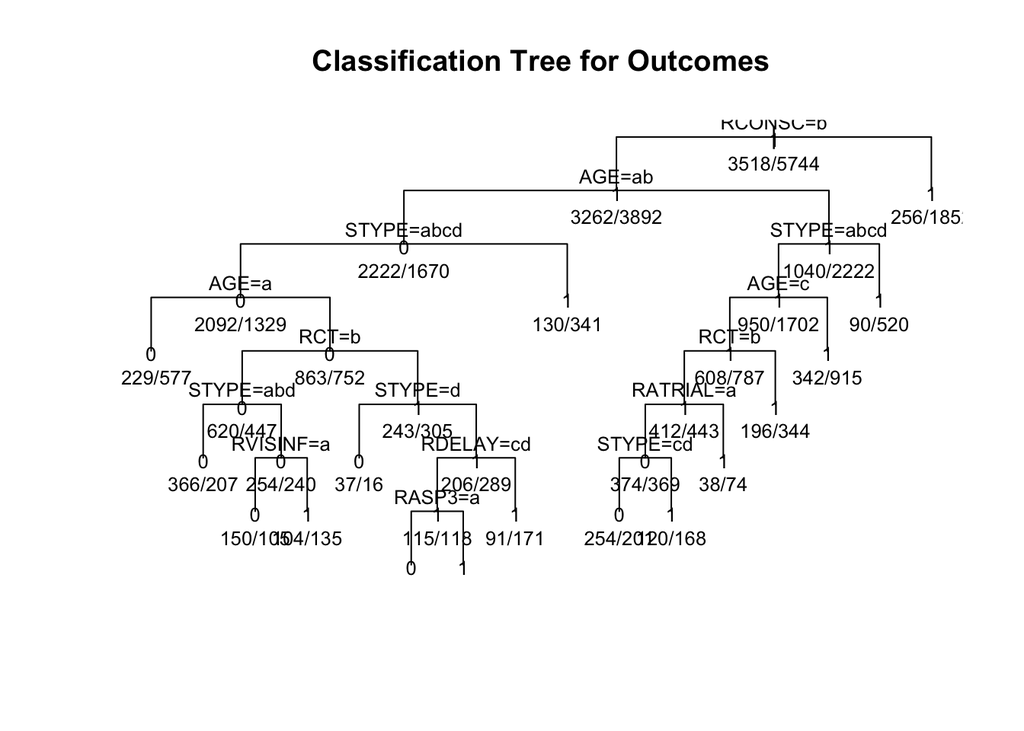

```r
# Plot the tree.
plot(dt2, uniform=TRUE, main="Classification Tree for Outcomes")
text(dt2, use.n=TRUE, all=TRUE, cex=.8)
```

```r
# Test the model.
predict.dt <- predict(dt2, test.dt) %>%
  as.data.frame

prediction.dt <- apply(predict.dt, 1, function(x){x[2] > x[1]})

summary.dt <- as.vector(prediction.dt) %>%
  table(test.dt$Outcome)
summary.dt
```

```
##
## .          0    1
##   FALSE 2120 1429
##   TRUE  1303 4337
```

```r
accuracy.dt <- (summary.dt[1,1]+summary.dt[2,2])/sum(colSums(summary.dt))
error.dt <- 1 - accuracy.dt
CI.dt.lower <- accuracy.dt - 1.96 * sqrt(error.dt*accuracy.dt/sum(colSums(summary.dt)))
CI.dt.upper <- accuracy.dt + 1.96 * sqrt(error.dt*accuracy.dt/sum(colSums(summary.dt)))

dt.report <- data.frame(accuracy.dt, CI.dt.lower, CI.dt.upper)
dt.report
```

```
##   accuracy.dt CI.dt.lower CI.dt.upper
## 1    0.702688   0.6933423   0.7120336
```

Construct an ROC (receiver operating characteristic) curve for each model and overlay them on a graph using ggplot. Include a legend.

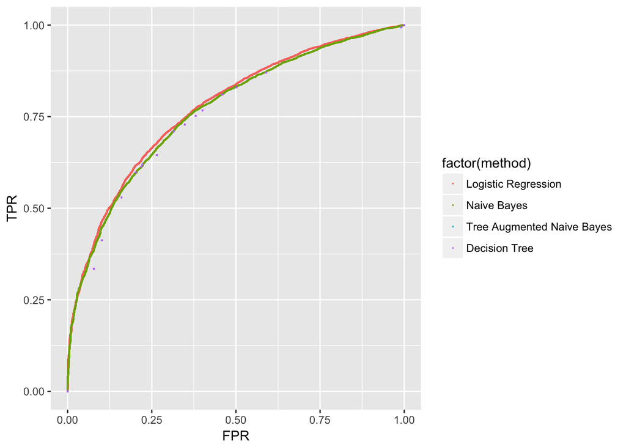

```r
library(ggplot2)

# Logistic Regression
lr.outcome <- data.frame(prob = predict.lr, obs = test.lr3$Outcome)
lr.outcome <- lr.outcome[order(lr.outcome$prob), ]

tpr.lr <- rep(0, nrow(lr.outcome))
fpr.lr <- rep(0, nrow(lr.outcome))

for (i in 1:nrow(lr.outcome)) {
    threshold.lr <- lr.outcome$prob[i]
    tp.lr <- sum(lr.outcome$prob > threshold.lr & lr.outcome$obs == 1)
    fp.lr <- sum(lr.outcome$prob > threshold.lr & lr.outcome$obs == 0)
    tn.lr <- sum(lr.outcome$prob < threshold.lr & lr.outcome$obs == 0)
    fn.lr <- sum(lr.outcome$prob < threshold.lr & lr.outcome$obs == 1)
    tpr.lr[i] <- tp.lr/(tp.lr+fn.lr)
    fpr.lr[i] <- fp.lr/(tn.lr+fp.lr)
}

# Naive Bayes
nb.outcome <- data.frame(prob = attr(predict.nb,"prob")[2,], obs = test.nb4$Outcome)
nb.outcome <- nb.outcome[order(nb.outcome$prob), ]

tpr.nb <- rep(0, nrow(nb.outcome))
fpr.nb <- rep(0, nrow(nb.outcome))

for (i in 1:nrow(nb.outcome)) {
    threshold.nb <- nb.outcome$prob[i]
    tp.nb <- sum(nb.outcome$prob > threshold.nb & nb.outcome$obs == 1)
    fp.nb <- sum(nb.outcome$prob > threshold.nb & nb.outcome$obs == 0)
    tn.nb <- sum(nb.outcome$prob < threshold.nb & nb.outcome$obs == 0)
    fn.nb <- sum(nb.outcome$prob < threshold.nb & nb.outcome$obs == 1)
    tpr.nb[i] <- tp.nb/(tp.nb+fn.nb)
    fpr.nb[i] <- fp.nb/(tn.nb+fp.nb)
}

# Tree Augmented Naive Bayes
tan.outcome <- data.frame(prob = attr(predict.tan,"prob")[2,], obs = test.tan$Outcome)
tan.outcome <- tan.outcome[order(tan.outcome$prob), ]

# The last prob in tan.outcome is NaN, so I just remove it.
tan.outcome <- tan.outcome[-which(is.nan(tan.outcome$prob)),]

tpr.tan <- rep(0, nrow(tan.outcome))
fpr.tan <- rep(0, nrow(tan.outcome))

for (i in 1:(nrow(tan.outcome)-1)) {
    threshold.tan <- tan.outcome$prob[i]
    tp.tan <- sum(tan.outcome$prob > threshold.tan & tan.outcome$obs == 1)
    fp.tan <- sum(tan.outcome$prob > threshold.tan & tan.outcome$obs == 0)
    tn.tan <- sum(tan.outcome$prob < threshold.tan & tan.outcome$obs == 0)
    fn.tan <- sum(tan.outcome$prob < threshold.tan & tan.outcome$obs == 1)
    tpr.tan[i] <- tp.tan/(tp.tan+fn.tan)
    fpr.tan[i] <- fp.tan/(tn.tan+fp.tan)
}


# Decision Tree
dt.outcome <- data.frame(prob = predict.dt[,2], obs = test.dt$Outcome)
dt.outcome <- dt.outcome[order(dt.outcome$prob), ]

tpr.dt <- rep(0, nrow(dt.outcome))
fpr.dt <- rep(0, nrow(dt.outcome))

for (i in 1:nrow(dt.outcome)) {
    threshold.dt <- nb.outcome$prob[i]
    tp.dt <- sum(dt.outcome$prob > threshold.dt & dt.outcome$obs == 1)
    fp.dt <- sum(dt.outcome$prob > threshold.dt & dt.outcome$obs == 0)
    tn.dt <- sum(dt.outcome$prob < threshold.dt & dt.outcome$obs == 0)
    fn.dt <- sum(dt.outcome$prob < threshold.dt & dt.outcome$obs == 1)
    tpr.dt[i] <- tp.dt/(tp.dt+fn.dt)
    fpr.dt[i] <- fp.dt/(tn.dt+fp.dt)
}

# ROC curve
ROCdata.lr <- data.frame(TPR = tpr.lr, FPR =fpr.lr, method = "Logistic Regression")
ROCdata.nb <- data.frame(TPR = tpr.nb, FPR =fpr.nb, method = "Naive Bayes")
ROCdata.tan <- data.frame(TPR = tpr.tan, FPR =fpr.tan, method = "Tree Augmented Naive Bayes")
ROCdata.dt <- data.frame(TPR = tpr.dt, FPR =fpr.dt, method = "Decision Tree")

ROCdata <- rbind(ROCdata.lr, ROCdata.nb, ROCdata.tan, ROCdata.dt)

ggplot(data = ROCdata, aes(x = FPR, y = TPR, color = factor(method))) +
         geom_point(size = 0.01) + xlim(0, 1)
```

Construct a PR (precision recall) curve for each model. Include a legend.

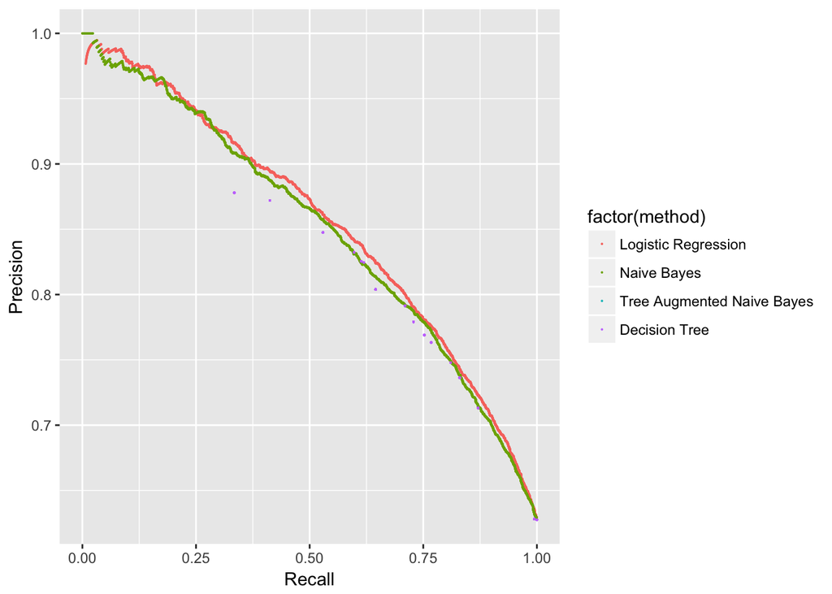

```r
# Logistic Regression

prec.lr <- rep(0, nrow(lr.outcome))

for (i in 1:nrow(lr.outcome)) {
    threshold.lr <- lr.outcome$prob[i]
    tp.lr <- sum(lr.outcome$prob > threshold.lr & lr.outcome$obs == 1)
    fp.lr <- sum(lr.outcome$prob > threshold.lr & lr.outcome$obs == 0)
    tn.lr <- sum(lr.outcome$prob < threshold.lr & lr.outcome$obs == 0)
    fn.lr <- sum(lr.outcome$prob < threshold.lr & lr.outcome$obs == 1)
    prec.lr[i] <- tp.lr/(tp.lr+fp.lr)
}


# Naive Bayes

prec.nb <- rep(0, nrow(nb.outcome))

for (i in 1:nrow(nb.outcome)) {
    threshold.nb <- nb.outcome$prob[i]
    tp.nb <- sum(nb.outcome$prob > threshold.nb & nb.outcome$obs == 1)
    fp.nb <- sum(nb.outcome$prob > threshold.nb & nb.outcome$obs == 0)
    tn.nb <- sum(nb.outcome$prob < threshold.nb & nb.outcome$obs == 0)
    fn.nb <- sum(nb.outcome$prob < threshold.nb & nb.outcome$obs == 1)
    prec.nb[i] <- tp.nb/(tp.nb+fp.nb)
}


# Tree Augmented Naive Bayes

prec.tan <- rep(0, nrow(tan.outcome))

for (i in 1:nrow(tan.outcome)) {
    threshold.tan <- tan.outcome$prob[i]
    tp.tan <- sum(tan.outcome$prob > threshold.tan & tan.outcome$obs == 1)
    fp.tan <- sum(tan.outcome$prob > threshold.tan & tan.outcome$obs == 0)
    tn.tan <- sum(tan.outcome$prob < threshold.tan & tan.outcome$obs == 0)
    fn.tan <- sum(tan.outcome$prob < threshold.tan & tan.outcome$obs == 1)
    prec.tan[i] <- tp.tan/(tp.tan+fp.tan)
}


# Decision Tree

prec.dt <- rep(0, nrow(dt.outcome))

for (i in 1:nrow(dt.outcome)) {
    threshold.dt <- nb.outcome$prob[i]
    tp.dt <- sum(dt.outcome$prob > threshold.dt & dt.outcome$obs == 1)
    fp.dt <- sum(dt.outcome$prob > threshold.dt & dt.outcome$obs == 0)
    tn.dt <- sum(dt.outcome$prob < threshold.dt & dt.outcome$obs == 0)
    fn.dt <- sum(dt.outcome$prob < threshold.dt & dt.outcome$obs == 1)
    prec.dt[i] <- tp.dt/(tp.dt+fp.dt)
}

# PR curve
PRdata.lr <- data.frame(Recall = tpr.lr, Precision = prec.lr, method = "Logistic Regression")
PRdata.nb <- data.frame(Recall = tpr.nb, Precision = prec.nb, method = "Naive Bayes")
PRdata.tan <- data.frame(Recall = tpr.tan, Precision = prec.tan, method = "Tree Augmented Naive Bayes")
PRdata.dt <- data.frame(Recall = tpr.dt, Precision = prec.dt, method = "Decision Tree")

PRdata <- rbind(PRdata.lr, PRdata.nb, PRdata.tan, PRdata.dt)

ggplot(data = PRdata, aes(x = Recall, y = Precision, color = factor(method))) +
         geom_point(size = 0.01) + xlim(0, 1)
```

#### Conclusions

Let’s draw conclusions from this study. Specifically,

- how well are we able to predict death or dependence at 6 months?

Regarding the accuracy, the four models have accuracy around 0.7, which means they do not perform very well on the prediction.

- what is the average treatment effect of aspirin on death or dependence at 6 months? Is aspirin significantly better than the alternative?

- of the algorithms tested, which algorithms perform the best? Justify your statement.

Congratulations, you’ve conducted a comparison of machine learning algorithms for mortality prediction! Commit your solutions to your git repository with an informative comment. `git push` will help you upload it to the cloud service you choose to use (github, bitbucket, etc).